# Tree basal area increment models for Cedrela, Amburana, Copaifera and Swietenia growing in the Amazon rain forests - ScienceDirect

[Advanced](https://www.sciencedirect.com/search)

## Figures (7)

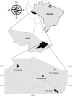

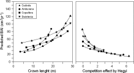

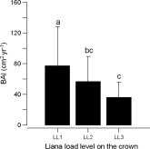

## [Forest Ecology and Management](https://www.sciencedirect.com/science/journal/03781127)

[Volume 365](https://www.sciencedirect.com/science/journal/03781127/365/supp/C), 1 April 2016, Pages 174-183

# Tree basal area increment models for *Cedrela*, *Amburana*, *Copaifera* and *Swietenia* growing in the Amazon rain forests

[Thiago Augustoda Cunha<sup>a</sup>](https://www.sciencedirect.com/science/article/pii/S0378112715007586#!)[César Augusto GuimarãesFinger<sup>b</sup>](https://www.sciencedirect.com/science/article/pii/S0378112715007586#!)[HubertHasenauer<sup>c</sup>](https://www.sciencedirect.com/science/article/pii/S0378112715007586#!)

https://doi.org/10.1016/j.foreco.2015.12.031[Get rights and content](https://s100.copyright.com/AppDispatchServlet?publisherName=ELS&contentID=S0378112715007586&orderBeanReset=true)

## Highlights

**•**

Tree growth functions for four commercial tree species of the Amazon [rain forest](https://www.sciencedirect.com/topics/agricultural-and-biological-sciences/rain-forests).

**•**

The species are *Cedrela*, *Amburana*, *Copaifera* and *[Swietenia](https://www.sciencedirect.com/topics/agricultural-and-biological-sciences/swietenia)*.

**•**

The key drivers are crown length, light conditions and liana load.

**•**

**•**

## Abstract

Little is known about sustainable forest management and tree growth in the Amazon forest. Reliable growth data from trees are very important in the context of forest management. Tree-characteristics such as architecture and competition are associated with diameter growth. Previous studies analyzing tree growth have indicated that these variables can describe these effects for temperate and boreal forests. However, the role of these effects for the growth of tropical trees needs to be enhanced for forest management practices. Here, we reconstructed the periodic annual basal area increment (*BAI<sub>i</sub>* cm<sup>2</sup> yr<sup>−1</sup>) of four long-lived timber species from the Amazon forest of Brazil: (i) *Cedrela odorata,* (ii) *Amburana cearensis,* (iii) *Copaifera pauper* and (iv) *Swietenia macrophylla* to investigate the growth development. The study focuses on (i) drivers important for individual tree growth, (ii) calibration of an individual tree basal area increment model for each of the four species, and (iii) assessing the practical implementation of our findings for enhancing sustainable forest management of these four tree species in the Amazon rainforest. The results exhibit a significant relationship between increasing basal area increment versus increasing crown length and decreasing competition expressed by Hegyi’s index. Trees sampled in densities greater than 25 m<sup>2</sup> ha<sup>−1</sup> had their *BAI*% significantly reduced. For *Cedrela* an additional negative impact on basal area increment from liana load is evident. Our findings reinforce the importance of release trees to obtain better crown exposure.

## Keywords

Amazon forest

Individual tree-growth

Forest management

## 1. Introduction

The Amazon forest in South America comprises one of the world’s largest biodiversity pools, and considerable efforts have been put in place to protect this forest. Nevertheless deforestation is still the major threat mainly because of the lack of knowledge in sustainable forest management (Godar et al., 2012).

The Brazilian Forest Service has established norms addressing sustainable forest management by ensuring biodiversity and conservation issues as well as providing saw-timber for commercial use (IBAMA, the agency responsible for forest policy and law enforcement, Normative Instruction 5, 2006). A practical guideline provides management practices by using a Minimum Cutting Diameter (*MCD*) of 50 cm, a cutting cycle of 25–35 years and an average reference increment rate of 0.86 m<sup>3</sup> ha<sup>−1</sup> yr<sup>−1</sup> for all commercial [forest tree](https://www.sciencedirect.com/topics/agricultural-and-biological-sciences/forest-trees) species. This regulation serves as a minimum harvesting requirement to avoid overcutting within the forest. It is important because the [Amazon rainforest](https://www.sciencedirect.com/topics/agricultural-and-biological-sciences/amazon-rainforest) is comprised of a large number of tree species, but only some of them are of commercial interest for the timber industry (nowadays an average of 20 species are usually harvested).

The practical problem of these regulations is that no information on species-specific changes in volume growth over time is available which limits sustainable forest management. This may lead to over cuttings or even an exploitation of high value tree species within such forests even if the “increment-reference-system” with a cutting cycle of 25–35 years (see IBAMA/Normative Instruction 5, 2006) is applied (Schöngart, 2008). This suggests that a species-specific silvicultural management and controlling system is needed to ensure sustainable wood production but also to address conservation issues of the forests.

A first step is to enhance our understanding of the annual increment rates by tree species, site, as well as stand conditions and implement these findings in simple species specific growth models to guide the Amazon forest management.

In [temperate forests](https://www.sciencedirect.com/topics/agricultural-and-biological-sciences/temperate-forest), annual increment rates and thus tree and stand age, are easy to determine due to the distinct seasonality and the appearance of the tree rings. However, within rainforests, tree rings may follow a different pattern and therefore they may not be usable as a measure of annual growth rates (Lieberman and Lieberman, 1985). This makes the determination of annual increment rates by tree species and stand age much more difficult. Previous studies on individual tree-growth in the Amazon forest were questioned due to this problem (e.g. Lieberman and Lieberman, 1985), while recent research based on [tree ring analysis](https://www.sciencedirect.com/topics/agricultural-and-biological-sciences/dendrochronology) has proven that annual tree rings exists for trees growing in the Amazon forest (Worbes, 1995). Tree rings are caused by the occurrence of a specific annual dry season (Brienen and Zuidema, 2005, Schöngart, 2008). This change from a wet to dry season evokes changes in [wood anatomy](https://www.sciencedirect.com/topics/agricultural-and-biological-sciences/wood-anatomy) and wood density (early wood, late wood) and turn the tree-ring more visible allowing for a measure of the annual diameter or individual tree [basal area](https://www.sciencedirect.com/topics/agricultural-and-biological-sciences/basal-area) increment rates (da Cunha, 2009, Fig. 1). Based on these findings, growth data collection and interpretation for developing growth models are possible for some trees of the Amazon forest.

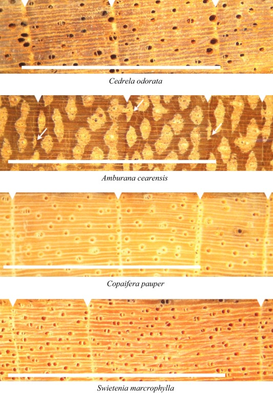

1. [Download : Download high-res image (977KB)](https://ars.els-cdn.com/content/image/1-s2.0-S0378112715007586-gr1_lrg.jpg)
2. [Download : Download full-size image](https://ars.els-cdn.com/content/image/1-s2.0-S0378112715007586-gr1.jpg)

Fig. 1. Macroscopic [wood anatomy](https://www.sciencedirect.com/topics/agricultural-and-biological-sciences/wood-anatomy) of object trees species showing ring boundaries (cava). For *Cedrela* marginal porous band occur at the beginning of the growth phase and presents diminution in [vessel diameter](https://www.sciencedirect.com/topics/agricultural-and-biological-sciences/vessel-diameter) with the proximity of the cambial dormancy. *[Swietenia](https://www.sciencedirect.com/topics/agricultural-and-biological-sciences/swietenia)* clear differ from *Cedrela* due uniform vessel diameters without marginal parenchyma bands. Tree rings characterized by alternating fiber bands with aliform paratracheal parenchyma turning narrow at the end of the growth phase (Arrows) in *Amburana*. Horizontal bars indicated 10 mm length. *Copaifera* presents axial parenchyma that contains axial porous from where canals secret oil-resin located in the late wood.

Growth models predict tree growth over time based on relationships between increment rates and potential drivers. Commonly such drivers are crown attributes, as a surrogate for the assimilation surface of a tree (Hasenauer and Monserud, 1996), competition variables for determining the competitive situation of a given tree versus its neighbors (Monserud and Sterba, 1996), as well as site conditions (see Wykoff, 1990, Choi et al., 2001). While lots of such studies and growth models have been developed for temperate forests as part of a sustainable forest planning tool (Hasenauer, 2006, Cole and Lorimer, 1994) a lack of models fitted to predict tree-growth using tree-size variables is evident for tropical rainforests.

The objective of this study is to provide information related to individual tree growth for four long-lived commercial tree species growing in the Amazon rainforest: *[Cedrela odorata](https://www.sciencedirect.com/topics/agricultural-and-biological-sciences/cedrela-odorata)*, Amburana cearensis, Copaifera paupera, and *Swietenia macrophylla*. We are specifically interested in (i) drivers important for individual tree growth, (ii) calibration of an individual tree basal area increment model for each of the four species, and (iii) assessing the practical implementation of our findings for enhancing sustainable forest management of these four tree species in the Amazon [rain forest](https://www.sciencedirect.com/topics/agricultural-and-biological-sciences/rain-forests).

## 2. Materials and method

### 2.1. Study area and data collection

Data for this study came from Acre, a state in the western corner of Brazil located in the [Amazon rainforest](https://www.sciencedirect.com/topics/agricultural-and-biological-sciences/amazon-rainforest). Four Annual Production Units (APU) were selected to collect the data (Fig. 2). An APU is defined as an annual planning unit for harvesting within the following year. It has a size of up to 400 ha. Commonly 25–35 m<sup>3</sup>/ha are cut by removing trees ⩾50 cm in *DBH* (diameter at breast height). Since a so called “reference increment” – defined with 0.86 m<sup>3</sup>/ha and a minimum *DBH* of 50 cm – is required for cutting (see IBAMA/Normative Instructions 7, 2006) the harvesting interval of an APU is about 30 years.

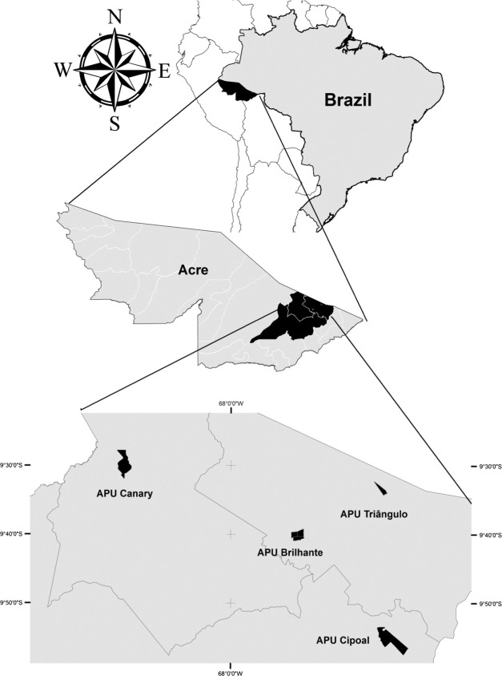

1. [Download : Download high-res image (202KB)](https://ars.els-cdn.com/content/image/1-s2.0-S0378112715007586-gr2_lrg.jpg)
2. [Download : Download full-size image](https://ars.els-cdn.com/content/image/1-s2.0-S0378112715007586-gr2.jpg)

Fig. 2. Location of the Annual Production Unit (APU) where the study was carried out.

*Source:* ZEE/AC-2006.

Each of the available APU (Annual Production Units) presents semi-deciduous forests with a mean [basal area](https://www.sciencedirect.com/topics/agricultural-and-biological-sciences/basal-area) of approximately 30 m<sup>2</sup>/ha and a mean height ranging between 30 and 35 m with some individuals reaching a top height of 45 m. The *DBH* can reach up to 2 m. The mean annual precipitation is 1800–2000 mm, with a mean annual temperature of 26 °C (Sombroek, 2001a, Sombroek, 2001b). From October to April strong rains are common, followed by three consecutive dry months. During these dry months (dry season peaks in July) the average rainfall is less than 50 mm per month (Sombroek, 2001a, Sombroek, 2001b). The dominant soils within the region are dystrophic oxisols with a high clay texture (D’Oliveira, 2000).

The four tree species selected for our study are: *C*. *odorata*; *S*. *macrophylla*; *A*. *cearensis* and *C*. *paupera* (hereafter referred to by genus only). The species belong to the group of major economic species in the region and are currently traded as timber. It is important to note that *[Swietenia](https://www.sciencedirect.com/topics/agricultural-and-biological-sciences/swietenia)* has been added to the list of [endangered species](https://www.sciencedirect.com/topics/agricultural-and-biological-sciences/endangered-species). Thus the harvest is only allowed under special conditions. *Cedrela* and *Swietenia* are leafless during the dry-season (July to September) and produce new leaves every year from October to November. According to Worbes, 1995, Dünisch et al., 2003, Brienen and Zuidema, 2005 annual tree rings are detectable for *Cedrela*, *Amburana, Swietenia, and Copaifera,* because trees show distinct growth periods, which are considered as annual tree-rings (Fig. 1).

### 2.2. Tree measurements

The tree data for this study were provided by a timber company and come from a forest inventory (Figueiredo et al., 2007). For each tree, the tree species, diameter at breast height and the tree location resulting from [GPS](https://www.sciencedirect.com/topics/earth-and-planetary-sciences/global-positioning-system) measurements are available. Trees were selected according to the following criteria: (i) covering one of our four different tree species, (ii) range in *DBH*, (iii) social position to address differences in the light regime, and (iv) variation in the differences of the tree’s competitive status. This resulted in 120 trees for *Cedrela*, 68 for *Amburana*, 70 for *Copaifera* and 45 for *Swietenia* carefully selected in order to cover the range of different development stages and growing conditions by species.

All the trees were grouped by *DBH* class at 20 cm intervals and localized and marked into the forest using a high-sensitivity GPS Sirf Star III technology. Each tree-coordinate was taken from the forest inventory map.

For each tree the *DBH* was recorded with a metric tape. Total tree height and height to the live crown base was recorded with an electronic hypsometer Vertex. Crown length is defined as the difference between total tree height and height to the live crown base. The crown diameter was measured in 8 directions and recorded with metric tape and a Suunto hypsometer to determine the vertical crown projection.

Crown Position Index (*CPI*), a measure for the light conditions of a tree within a stand (Davies et al. 1998), was recorded after modifying the classification of Dawkins (1963) to three light classes:

*CPI* 1 = emergent crown with direct light from above as well as lateral light;

*CPI* 2 = light from above the canopy, but no lateral light due to competition;

*CPI* 3 = no direct sun light.

The Crown Position Index (*CPI*) exhibits a good correlation with the canopy openness in non-managed native forests (Davies et al., 1998). Note that the *CPI* is not comparable with the common tree classification system for [temperate and boreal forests](https://www.sciencedirect.com/topics/agricultural-and-biological-sciences/temperate-forest) proposed by Kraft (1884). The growth of trees in the Amazon [rain forest](https://www.sciencedirect.com/topics/agricultural-and-biological-sciences/rain-forests) depends not only on the light regime from above. It also is strongly driven by lateral incoming radiation. This is explicitly addressed with the *CPI* classification scheme.

The occurrence of liana load (*LL*) on a crown was recorded for each species to analyze potential effects of liana load on tree growth (Schnitzer and Bongers, 2002). The classification were done by using three groups:

*LL*1 – trees with no liana or less than 50% covered in the crown;

*LL*2 – 50–75% of the crown covered with liana;

*LL*3 ⩾ 75% of the crown is covered with liana.

Table 1 provides the summary statistics of the collected field data available for our study.

Table 1. Summary statistics of the data including the mean, the minimum and maximum values (in parenthesis) available for this study.

| Variables | Tree species *Cedrela odorata* | Tree species *Amburana cearensis* | Tree species *Copaifera palpera* | Tree species *Swietenia macrophylla* |
| --- | --- | --- | --- | --- |
| *N* sampled | 120 | 68 | 70 | 45 |
| Light requirement<sup>a</sup> | Intermediate | Intermediate | Shade tolerant | Shade tolerant |
| Successional status<sup>b</sup> | Long-lived pioneer | Long-lived pioneer | Late successional | Long-lived pioneer |
| Adult stature<sup>c</sup><sup>,</sup><sup>d</sup> | Canopy | Canopy | Emergent | Canopy |
| Wood density<sup>e</sup> | 0.39 | 0.47 | 0.62 | 0.52 |
| Density (tree/ha)<sup>f</sup> | 0.55 | 0.25 | 0.16 | 0.03 |
| *DBH* (cm) | 61.5 (13.3–132.1) | 55.5 (13.2–106.1) | 70.7 (36.7–138.7) | 71.8 (31.0–121.8) |
| *H* (m) | 28.9 (12.1–49.1) | 28.1 (8.0–40.1) | 31.6 (20.9–44.3) | 28.1 (15.5–39.9) |
| Crown length (m) | 10.3 (2.9–20.1) | 5.9 (1.5–13.2) | 7.5 (3.2–14.7) | 7.8 (3.9–14.1) |
| Crown diameter (m) | 14.7 (2.9–33.2) | 13.3 (4.5–25.2) | 20.4 (8.7–36.5) | 16.5 (5.4–32.6) |
| *BAI* (cm<sup>2</sup>/year) | 61.3 (8.2–200.8) | 45.5 (8.8–127.5) | 55.9 (15.1–133.6) | 63.1 (19.7–143.1) |
| Productivity (*BAI*%) | 2.9 (0.2–11.1) | 2.7 (0.8–10.5) | 1.8 (0.2–6.4) | 1.9 (0.4–4.6) |
| Competition (Hegyi index) | 1.8 (1.0–7.3) | 1.4 (1.0–6.5) | 1.23 (1.0–3.4) | 1.2 (1.0–3.3) |
| CPI | (1–3) | (1–3) | (1–2) | (1–2) |
| Liana load | (1–3) | (1–1) | (1–2) | (1–3) |

*CPI* and liana load do not have mean values because they are discrete values.

**a**

Classified according to Poorter (1999).

**b**

Classified according to Griscom and Ashton (2011).

**c**

Classified according to Rheenen et al. (2004).

**d**

Classified according to Brienen and Zuidema (2005).

**f**

Density of the forest surveyed calculated considered *DBH* above 30 cm.

**e**

Database of Brazilian woods, Brazilian Institute of Environment and Renewable Natural Resources – IBAMA.

### 2.3. Tree competition measures

Individual tree growth strongly depends on the level of competition which can be expressed by competition indices derived from routine inventory data. Competition measures define the competitive situation of a given tree within a stand for limited resources (light, water, nutrition, etc.) (Tomé and Burkhart, 1989). We assess the competitive status for each sampled tree using the concept of [asymmetric competition](https://www.sciencedirect.com/topics/earth-and-planetary-sciences/asymmetric-competition) (Schwinning and Weiner, 1998, Freckleton and Watkinson, 2001, Mitsuda et al., 2002). This approach defines a distance to an active competitors (*Dist<sub>ij</sub>*) of a subject tree (*i*) to those neighbors (*j*) whose total height (*h<sub>i</sub>*) is greater than an imaginary inclined line traced from the object tree’s live crown base (*hbc<sub>i</sub>*) with a 45° angle, defined as tan(45°) (see Fig. 3).

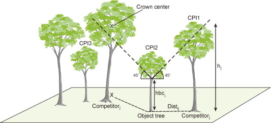

1. [Download : Download high-res image (266KB)](https://ars.els-cdn.com/content/image/1-s2.0-S0378112715007586-gr3_lrg.jpg)
2. [Download : Download full-size image](https://ars.els-cdn.com/content/image/1-s2.0-S0378112715007586-gr3.jpg)

Fig. 3. Criteria for selecting the competitor trees. The height *h<sub>j</sub>* was corrected in case of slopes. *CPI* 1, *CPI* 2, *CPI* 3 are the crown position indices 1, 2, 3, *hbc<sub>j</sub>* = height to the live crown base, *Dist<sub>ij</sub>* = distance between the object (*Object tree*) and the competitor tree (*Competitor<sub>j</sub>*).

Every tree within the angle of a given subject tree is considered as an active competitor for that subject tree (see Fig. 3) and can be defined as:(1)$tan45°=hj-hbciDistij=1⇒(hj-hbci>Distij)$

Next the competition situation for each of our selected sample trees was derived according to Hegyi (1974). This so called Hegyi index defines the relationship between the *DBH* from the competitor “*j*” and the object tree “*i*” weighted by the horizontal distance between the trees. We follow the suggestion by Sabatia and Burkhart (2012) who modified the formula by adding the exponent 0.5 to the distance:(2)$Hegyi=∑j=1nDBHjDBHi×Distij0.5$

This index assumes that the competition effects of neighboring trees increases with increasing breast height diameter of the competitor (*DBH<sub>j</sub>*) and decreasing distance (*Dist<sub>ij</sub>*) between the subject tree ‘*i*’ and respective competitors ‘*j*’.

Stand density was assessed for each subject tree to determine the resulting impact on growth by using the concept of *Density Point Measure* (*DPA*). We compare the tree productivity with the competition and derive how a given competitive situation will affect tree growth. *DPA* is an angle sum method as proposed by Spurr (1962) and may be seen as a modified angle count method (Bitterlich, 1984), which considers that the mean basal area per hectare ($BA‾$) can be calculated as:(3)$BA‾=∑i=inn-12×DBHjDistij24n$where *n* represents the number of selected competitor trees according to Eq. (1), *DBH<sub>j</sub>* is the diameter at breast height of the competitor, and *Dist<sub>ij</sub>* is the distance between the subject tree *i* and its competitor *j*.

### 2.4. Deriving individual tree growth

For each tree two increment cores (10 cm length and 5 mm width) were extracted at 1.3 m between July and October. If the trees exhibited tabular roots (“sapopemas” common for *Cedrela* and *Swietenia*) the cores were extracted 30 cm above (Metcalf et al., 2008). The tree-ring growth was visually cross-dated using the increment cores (Stokes and Smiley, 1996) and the annual radial increment was recorded for the last 4 years to the nearest 0.01 mm by using Lintab II (Frank Rinn S.A. Heidelberg, Germany) and TSAP-Win software (Rinn, 2003). For this time period (four years) it was assumed that the canopy structure and competition within our forests was constant. Next we reconstructed the 4 year radial increment from the current *DBH* to derive the diameter increment (*i<sub>d</sub>*) of the past four years and the previous diameter at breast height (*DBH*<sub>1</sub>) by subtracting *i<sub>d</sub>*. With this information we can calculate the observed periodic mean average annual basal area increment for each tree (*BAI<sub>i</sub>* cm<sup>2</sup> yr<sup>−1</sup>) of the last four years (Assmann, 1970):(4)$BAIi=π42·DBHi·id+id24$

The relative increment of each tree (*BAI*%) can be derived as(5)$BAI%=BAIi(BA2+BA1)2∗100$where *BAI<sub>i</sub>* is the 4 year basal area increment *BA*<sub>1</sub> the basal area at the beginning and *BA*<sub>2</sub> the basal area at the end of the 4 year growing period. This procedure will allow an approximation of the time required to produce the target diameter for cutting (Wadsworth et al., 2010).

### 2.5. Construction of a tree basal area increment model

To assess the potential drivers of individual tree growth we started with an explorative data analysis seeking simple drivers by a correlation analysis ran between our tree basal area increment (*BAI*) versus (i) tree-size variables, (ii) competition measures, and (iii) the liana load. This correlation was plotted to permit graphical assessment of the species specific association among the variables and to formulate the following general individual tree basal area increment model:(6)$ln(BAI)=a+bi×(Treesize)+ci×(Comp)+di×(LL)$where the ln(*BAI*) is the natural logarithm of the four year basal area increment from each tree, *a* is the intercept, *b<sub>i</sub>* is the vector of coefficients for the tree size variables (*Treesize*), *c* is the vector of the coefficients for the tree competition measures (*Comp*), and *d* is the coefficient to evaluate the liana load effect (*LL*) on tree growth. Note that *LL* is used as a dummy variable and characterize the three *LL* groups.

The vector for *Treesize* includes the diameter at breast height (*DBH*), total tree height (*h*), crown diameter (*cd*), and crown length (*cl*). The vector for *Comp* comprises Hegyi’s competition index (see Eq. (2)) and the Crown Position Index (*CPI*).

## 3. Results

### 3.1. Species-specific drivers for tree growth

We analyzed the correlation between expected independent drivers versus the periodic (four years) annual tree [basal area](https://www.sciencedirect.com/topics/agricultural-and-biological-sciences/basal-area) increment (*BAI<sub>i</sub>*). The results from Pearson’s correlations of *BAI<sub>i</sub>* versus the tree-size variables, (i) diameter at breast height (*DBH*), (ii) height (*h*), (iii) crown length (*cl*) and (iv) crown diameter (*cd*) revealed significant (*α* = 0.05) relationships for all trees species. The same procedure was applied for the individual tree competition measures according to (i) Hegyi index (see Eq. (2)), and (ii) the Crown Position Index (*CPI*). Finally the same procedure was applied to test whether or not liana load (*LL*) has any influence on tree growth. Note that no liana load was recorded for *Amburana* (Table 2).

Table 2. Pearson correlation between [basal area](https://www.sciencedirect.com/topics/agricultural-and-biological-sciences/basal-area) increment (*BAI*) versus *DBH* (Diameter at breast height), *H* (tree height), crown length (*CL*), crown diameter (*CD*), the Hegyi Index, Crown Position Index (*CPI*), and liana load (*LL*) by species. All correlations are significant at *α* = 0.05 besides those indicated as ns (non-significant).

| Variable | Species evaluated *Cedrela* | Species evaluated *Amburana* | Species evaluated *Copaifera* | Species evaluated *Swietenia* |
| --- | --- | --- | --- | --- |
| *DBH* (cm) | 0.365 | 0.693 | 0.375 | 0.507 |
| *H* (m) | 0.441 | 0.656 | 0.237 | 0.374 |
| *CL* (m) | 0.390 | 0.556 | 0.300 | 0.205 |
| *CD* (m) | 0.389 | 0.685 | 0.389 | 0.501 |
| Hegyi index | −0.429 | −0.390 | −0.294 | −0.305 |
| *CPI* | −0.495 | −0.436 | −0.492 | −0.439 |
| *LL* | −0.353 | – | −0.031<sup>ns</sup> | −0.006<sup>ns</sup> |

### 3.2. Calibration of tree basal area increment models

The results of Table 2 provide the potential “drivers” to calibrate a basal area increment model for each tree species according to Eq. (6) by species. All variables selected had to be significant at *α* = 0.05. Multicollinearity was controlled by requiring a variance inflation factor (VIF) to be less than 5 for each predictor variable. The VIF for the *i*th [regression coefficient](https://www.sciencedirect.com/topics/earth-and-planetary-sciences/regression-coefficient) is simply the *i*th diagonal element of the inverse of the correlation matrix (Snee, 1973) and represents the increase in the variance due to the correlation between the predictors (Marquardt, 1970, Van Laar, 1991). A large VIF (e.g. >5) indicates a strong correlation between certain predictor variables. This situation can produce misleading results because it does not provide adequate independent information for reliable predictions (Snee, 1973). We employed multiple linear regressions using PROC REG to calculate the variance inflation factor VIF of the independent variables (SAS Institute Inc., 2009). For each tree species we started with the full set of variable and removed one variable after the other, each with a separate regression run, if either *α* > 0.05 or if VIF > 5. This resulted in species-specific increment functions.

*BAI<sub>i</sub>* data exhibit increasing variance with tree-size variables therefore the coefficients of the final models were calibrated using a Gamma distribution (e.g. Gea-Izquierdo and Cañellas, 2009, Contreras et al., 2011). After retransforming Eq. (6) in its nonlinear form the Gamma distribution enables us to directly model the selected dependent variable by avoiding a potential bias of the transformed models (Table 3). Crown length and Hegiys competition index entered the model significantly. Only for *Cedreala* Liana Load (*LL*2, and *LL*3), used as a dummy variable, additionally entered the individual tree basal area increment model.

Table 3. Species specific parameter estimates for the growth models plus the corresponding fit statistics. All the parameters shown have a variance inflation vector VIF of <5 to control multicollinearity and are significant at *α* = 0.05.

| Variables | Species evaluated *Cedrela* | Species evaluated *Amburana* | Species evaluated *Copaifera* | Species evaluated *Swietenia* |
| --- | --- | --- | --- | --- |
| Intercept | 5.9311 | 3.5140 | 4.0725 | 4.4084 |
| Crown length (*CL*) | 0.0349 | 0.0912 | 0.0399 | 0.0266 |
| Hegyi index | −0.3469 | −0.2020 | −0.3000 | −0.4044 |
| Liana load (*LL*2) | −0.3402 | – | – | – |
| Liana load (*LL*3) | −0.7328 | – | – | – |
| $ϕ$ | 0.290 | 0.130 | 0.205 | 0.205 |
| *AICC* | 1465.1 | 569.8 | 646.9 | 430.3 |
| *R*<sup>2</sup> | 0.48 | 0.47 | 0.14 | 0.16 |
| *RMSE* | 5.73 | 1.63 | 3.40 | 3.98 |

$BAI=exp(a+b×CL+c×Hegyi+di×LL).$

$ϕ$ dispersion parameter in GLM. This measures the dispersion of the distribution.

*AICC* is the corrected Akaikes’s Information Criterion, lower values are an indicator for better models.

*R*<sup>2</sup> coefficient of determination.

*RMSE* root of the mean square error.

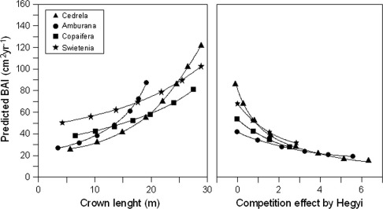

1. [Download : Download high-res image (90KB)](https://ars.els-cdn.com/content/image/1-s2.0-S0378112715007586-gr4_lrg.jpg)
2. [Download : Download full-size image](https://ars.els-cdn.com/content/image/1-s2.0-S0378112715007586-gr4.jpg)

Letters indicated significant differences according to the Tukey test (*α* = 0.05) in mean *BAI* between *LL*1 and *LL*2 as well as *LL*3 but no differences between *LL*2 and LL3 (Fig. 5). Note that the Tukey test was performed using the recorded liana load data.

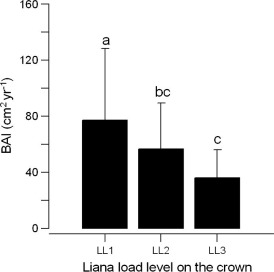

1. [Download : Download high-res image (38KB)](https://ars.els-cdn.com/content/image/1-s2.0-S0378112715007586-gr5_lrg.jpg)
2. [Download : Download full-size image](https://ars.els-cdn.com/content/image/1-s2.0-S0378112715007586-gr5.jpg)

Fig. 5. [Basal area](https://www.sciencedirect.com/topics/agricultural-and-biological-sciences/basal-area) increment (*BAI*) for *Cedrela* by Liana Load classes: LL1 no lianas, *n* = 44; *LL*2 50% crown covered with liana; *n* = 55, *LL*3 ⩾ 75% crown covered with liana, *n* = 21. Letters indicated statistically significant differences at *α* < 0.05. Error bars represent the standard deviation in [Mead](https://www.sciencedirect.com/topics/agricultural-and-biological-sciences/mead) *BAI*. The results of a adjust Tukey–Kramer test (*Pr* > *F* = 0.0004) indicate a significant difference in Mean *BAI* between *LL*1 and *LL*2 as well as between *LL*1 and *LL*3 but no significant differences between *LL*2 and *LL*3. The ANOVA was done with the *BAI* observed data.

### 3.3. Management implications

An important task of the study is to provide practical solutions for implementing sustainable forest management options for our four investigated tree species. The Crown Position Index (*CPI*) (Dawkins, 1963), did not enter the basal are increment equations significantly (see Table 3). For each tree species the *BAI* (tree basal are increment) differs by *CPI* (social position), and *DBH* class (Fig. 6). The *MCD* (Minimum Cutting Diameter) according to the Brazilian forest law (IBAMA/Normative Instruction 5, 2006) requires a *DBH* ⩾ 50 cm.

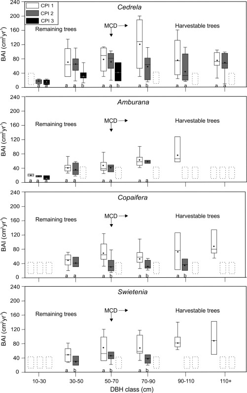

1. [Download : Download high-res image (315KB)](https://ars.els-cdn.com/content/image/1-s2.0-S0378112715007586-gr6_lrg.jpg)
2. [Download : Download full-size image](https://ars.els-cdn.com/content/image/1-s2.0-S0378112715007586-gr6.jpg)

Fig. 6. Species specific basal are increment (*BAI*) by *DBH* classes. The minimum and maximum as well as 25 and 75 percentile *BAI* by different light regimes expressed as the Crown Position Index (CPI) also are presented. *MCD* = is the minimum cutting diameter (in Brazil the Forest Law prescribes *MCD* of 50–70 depending on the specie). The letters bellow each box refer to the results of the adjusted Tukey–Kramer test. Different letters indicate significant (*α* = 0.05) *BAI* increment rates between *CPI* classes within a given *DBH* range. Mean (♦). Dotted boxes indicated light conditions not sampled. The sample sizes by *DBH* classes are (minimum and maximum): *Cedrela* 6–30; *Amburana* 3–20; *Copaifera* 6–21; *[Swietenia](https://www.sciencedirect.com/topics/agricultural-and-biological-sciences/swietenia)* 4–13.

The response to crown release differs by the competitive situation of a tree within a stand (Fig. 6). Thus we were interested in assessing the productivity potential and the time required in achieving a certain target diameter e.g. the *MCD* (Minimum Cutting Diameter) by obtaining the results of Eq. (3) for assessing the productivity potential *PBAI<sub>i</sub>* in percent defined as:(7)$PBAIi(%)=BAIi/BAi·100$where *BAI<sub>i</sub>* the tree basal area increment from Eq. (3) and *BA<sub>i</sub>* the tree basal area of the subject tree at the beginning of the growth period.

Our data covered a wide variety of stand density situations so we are interested in the confidence interval or “corridor” of our species-specific growth functions. The confidence interval *CI* for the mean of the differences *D* (predicted − observed) can be used to evaluate discrepancies between the expected difference and the estimator $D‾$ (Reynolds, 1984):(8)$CI=D‾±SDn·t1-α/2,(n-1)$where $D‾$ is the mean, *S<sub>D</sub>* the standard deviation of the *D<sub>i</sub>* differences, *n* is the sample size and *t* is the 1 − *α*/2 [quantile](https://www.sciencedirect.com/topics/earth-and-planetary-sciences/quantiles) of the *t*-distribution with *n* − 1 degrees of freedom.

For practical silvicultural decision making one of the key questions is the time it takes to grow a given tree from a certain starting diameter to an expected target diameter. With the results of the regression analysis (Table 3) the four year increment rates according to tree and competition attributes are predictable for each tree within a stand. With this information we can estimate the number of years (*t*) required to grow a given tree with a basal area corresponding to a *DBH* = 30 cm (*BA<sub>i</sub>*) to the basal area of a tree with a *DBH* = 50 cm (*BA<sub>i+</sub>*<sub>1</sub>) by obtaining the relative increment rates (*PBAI*%) of Eq. (7). This procedure follows the compound interest law as proposed by Schneider and Schneider (2008) and can be expressed as:(9)$BAi+1=(1+PBAI%)t·BAi∴t=ln(BAi+1)-ln(BAi)ln(1+PBAI%)$where ln is the natural logarithm and all other variables are as previously defined. Again the confidence interval was calculated to express the range for future predictions (Table 5).

The access to direct sunlight expressed by a crown position index of 1 (*CPI* = 1) is essential to enhance tree growth and thus reaching the Minimum Cutting Diameter (*MCD* = 50 cm) for harvesting within a minimum time e.g. the lowest number of years for growing a tree from 30 to 50 cm in *DBH* (Table 5). From a practical forest management perspective a simple relationship between tree competition (e.g. Crown Position Index – *CPI*) and forest density is required. Thus we obtain the estimated relative potential productivity (Eq. (7)) for each tree and group them in 5 forest density classes: <10 m<sup>2</sup> ha<sup>−1</sup>, 10–15, 16–20, 21–25, and >25 m<sup>2</sup> ha<sup>−1</sup>). We did not separate our results by tree species because the Brazilian Forest Service also uses only general forest density measures (IBAMA/Normative Instructions 5, 2006) (Fig. 7). The Tukey–Kramer test revealed a significant reduction in mean productivity if the basal area and thus forest density is ⩾25 m<sup>2</sup> ha<sup>−1</sup>.

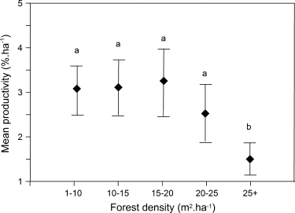

1. [Download : Download high-res image (62KB)](https://ars.els-cdn.com/content/image/1-s2.0-S0378112715007586-gr7_lrg.gif)
2. [Download : Download full-size image](https://ars.els-cdn.com/content/image/1-s2.0-S0378112715007586-gr7.gif)

Fig. 7. Relative basal are increment potential for each tree (*PBAI*%) versus forest density classes of the surrounding trees in m<sup>2</sup> h<sup>−1</sup>, and the 95% confidence intervals. The letters indicate the results of the adjusted Tukey–Kramer test. The growth of trees growing in the forest density class +25 m<sup>2</sup> is significantly lower vs. the tree growth in all other classes. Note that in this figure provides an average across all species because the official management guidelines also do not provide species specific numbers.

## 4. Discussion

*Cedrela, Copaifera* and *Swietenia* exhibit a similar behavior between *BAI* (tree Basal Area Increment) vs. Crown Length while the *BAI* crown length development of *Amburana* is much more sensitive to changes in crown length (Fig. 4 left). *BAI* vs. Hegyi’s competition index (Fig. 4 right) exhibits an exponential decline with increasing competition following a similar pattern for all four tree species. Hegyi’s competition index (Hegyi, 1974) was originally developed for pure uniform stands. According to our results we show that this concept is also applicable for trees growing in mixed species stands of the Amazon rain forest.

Table 4. Effect of social position (*CPI*) in the annual tree [basal area](https://www.sciencedirect.com/topics/agricultural-and-biological-sciences/basal-area) increment productivity (*PBAI*) in percent by species. The values for the basal area increment were calculated for *DBH* class of 30–50 cm. Where mean is the mean value for the available data and min and max give at a 95% probability level of the confidence interval (*CI*) and provide the range or “corridor” in future predictions. Sample size for the species are: *Cedrela* = 120; *Amburana* = 68; *Copaifera* = 70 and *[Swietenia](https://www.sciencedirect.com/topics/agricultural-and-biological-sciences/swietenia)* = 45.

| Spieces | Tree basal are increment productivity – *PBAI* (%) *CPI* 1 Mean | Tree basal are increment productivity – *PBAI* (%) *CPI* 1 (min–max) | Tree basal are increment productivity – *PBAI* (%) *CPI* 2 Mean | Tree basal are increment productivity – *PBAI* (%) *CPI* 2 (min–max) | Tree basal are increment productivity – *PBAI* (%) *CPI* 3 Mean | Tree basal are increment productivity – *PBAI* (%) *CPI* 3 (min–max) |
| --- | --- | --- | --- | --- | --- | --- |
| *Cedrela* | 6.1 | 3.9–8.2 | 5.6 | 4.1–7.1 | 2.9 | 1.8–4.1 |
| *Amburana* | 4.1 | 3.1–5.1 | 2.9 | 2.0–3.9 | – | – |
| *Copaifera* | 3.7 | 2.6–4.8 | 3.5 | 2.5–4.4 | – | – |
| *Swietenia* | 4.7 | 1.0–8.5 | 2.8 | 1.0–4.6 | – | – |

| Species | Number of years to grow from *DBH* 30 to 50 cm (years) *CPI* 1 Mean | Number of years to grow from *DBH* 30 to 50 cm (years) *CPI* 1 (min–max) | Number of years to grow from *DBH* 30 to 50 cm (years) *CPI* 2 Mean | Number of years to grow from *DBH* 30 to 50 cm (years) *CPI* 2 (min–max) | Number of years to grow from *DBH* 30 to 50 cm (years) *CPI* 3 Mean | Number of years to grow from *DBH* 30 to 50 cm (years) *CPI* 3 (min–max) |
| --- | --- | --- | --- | --- | --- | --- |
| *Cedrela* | 17 | 13–27 | 19 | 15–25 | 36 | 25–57 |
| *Amburana* | 25 | 21–34 | 36 | 27–52 | – | – |
| *Copaifera* | 28 | 22–40 | 30 | 24–41 | – | – |
| *Swietenia* | 22 | 13–105 | 37 | 23–103 | – | – |

High productivity was evident for all species with enough available light (Table 4). For example a *Cedrela* tree with a *DBH* of 30 cm and a crown in full light conditions (above and lateral, *CPI* 1) showed a production rate of 6.1%. When the light condition changes to no direct sun light in the crown (*CPI* 3, see Table 5) a tree with a *DBH* of 30 cm will need approximately 19 years more to reach 50 cm in *DBH*. This attribute has important implications in the [timber production](https://www.sciencedirect.com/topics/earth-and-planetary-sciences/forestry-production). In this way Brienen and Zuidema (2006), emphasizes the technical benefits and the [economic viability](https://www.sciencedirect.com/topics/earth-and-planetary-sciences/economic-viability) of tree liberation activity to improved future yield of the forest.

From a practical purposes the results of Table 4, Table 5 are important since the relative annual basal area increment by species in tree growth are provided. Productivity starts to decline at a basal area of about 20–25 m<sup>2</sup> ha<sup>−1</sup> and significantly falls off at >25 m<sup>2</sup> ha<sup>−1</sup> (Fig. 7). This density range suggests that stand density should be kept at this or below this basal area to ensure the highest growth rates. Our findings confirm the results of Wadsworth et al. (2010). In their practical guidelines a stand density of approximately 25 m<sup>2</sup> ha<sup>−1</sup> is suggested.

## Acknowledgements

The first draft of this paper was written during a research visit of the first author at the Institute of [Silviculture](https://www.sciencedirect.com/topics/agricultural-and-biological-sciences/silviculture), BOKU University of Natural Resources and Life Sciences Vienna, Austria. This visit was financially supported by the Capes Foundation, Ministry of Education of Brazil and the Universidade Federal de Santa Maria as a part of the doctored project. The paper was finished during the sabbatical of Prof Cesar Finger at the Institute of Forest Growth Research at BOKU. We thank Frank Wadsworth for helping to review the manuscript.

## References

**Assmann, 1970**

E. Assmann

**The Principles of Forest Yield Studies**

Pergamon Press (1970)

492p

[Google Scholar](https://scholar.google.com/scholar_lookup?title=The%20Principles%20of%20Forest%20Yield%20Studies&publication_year=1970&author=E.%20Assmann)

**Bitterlich, 1984**

W. Bitterlich

**The Relascope Idea: Relative Measurements in Forest**

CABI (1984)

256p

[Google Scholar](https://scholar.google.com/scholar_lookup?title=The%20Relascope%20Idea%3A%20Relative%20Measurements%20in%20Forest&publication_year=1984&author=W.%20Bitterlich)

**Brienen and Zuidema, 2005**

R.J.W. Brienen, P.A. Zuidema

**Relating tree growth to rainfall in Bolivian rain forests: a test for six species using tree ring analysis**

Oecologia, 146 (2005), pp. 1-2

[CrossRef](https://doi.org/10.1007/s00442-005-0160-y)[View Record in Scopus](https://www.scopus.com/inward/record.url?eid=2-s2.0-27644514668&partnerID=10&rel=R3.0.0)Google Scholar

**Brienen and Zuidema, 2006**

R.J.W. Brienen, P.A. Zuidema

**The use of tree rings in tropical forest management: projecting timber yields of four Bolivian tree species**

For. Ecol. Manage., 226 (2006), pp. 256-267

[Article](https://www.sciencedirect.com/science/article/pii/S0378112706000867)[Download PDF](https://www.sciencedirect.com/science/article/pii/S0378112706000867/pdfft?md5=d0785421aae3fc70cbaba6bc1abd4fb7&pid=1-s2.0-S0378112706000867-main.pdf)[View Record in Scopus](https://www.scopus.com/inward/record.url?eid=2-s2.0-33646474837&partnerID=10&rel=R3.0.0)Google Scholar

**Choi et al., 2001**

J. Choi, C.G. Lorimer, J. Vanderwerker, W.G. Cole, G.L. Martin

**A crown model for simulating long-term stand and gap dynamics in northern hardwood forests**

For. Ecol. Manage., 152 (2001), pp. 235-258

[Article](https://www.sciencedirect.com/science/article/pii/S037811270000606X)[Download PDF](https://www.sciencedirect.com/science/article/pii/S037811270000606X/pdfft?md5=70984fe8f08098e2b620882447668792&pid=1-s2.0-S037811270000606X-main.pdf)[View Record in Scopus](https://www.scopus.com/inward/record.url?eid=2-s2.0-0035887761&partnerID=10&rel=R3.0.0)Google Scholar

**Clark and Clark, 1990**

D.B. Clark, D.A. Clark

**Distribution and effects on tree growth of lianas and woody hemiepiphytes in a Costa Rican tropical wet forest**

J. Trop. Ecol., 6 (1990), pp. 321-331

[View Record in Scopus](https://www.scopus.com/inward/record.url?eid=2-s2.0-0025626875&partnerID=10&rel=R3.0.0)Google Scholar

**Cole and Lorimer, 1994**

G.C. Cole, C.G. Lorimer

**Predicting tree growth from crown variables in managed northern hardwood stands**

For. Ecol. Manage., 67 (1994), pp. 159-175

[View Record in Scopus](https://www.scopus.com/inward/record.url?eid=2-s2.0-0028160829&partnerID=10&rel=R3.0.0)Google Scholar

**Contreras et al., 2011**

M.A. Contreras, D. Affleck, W. Chung

**Evaluating tree competition indices as predictors of basal area increment in western Montana forests**

For. Ecol. Manage., 262 (2011), pp. 1939-1949

[Article](https://www.sciencedirect.com/science/article/pii/S0378112711005238)[Download PDF](https://www.sciencedirect.com/science/article/pii/S0378112711005238/pdfft?md5=3d8a43ade3ad7ae83a876599c0b697cb&pid=1-s2.0-S0378112711005238-main.pdf)[View Record in Scopus](https://www.scopus.com/inward/record.url?eid=2-s2.0-80053365596&partnerID=10&rel=R3.0.0)Google Scholar

**da Cunha, 2009**

da Cunha, T.A., 2009. Modeling the growth of individual Cedrela odorata L. trees in Amazon rainforest. Master’s Thesis. UFSM, Santa Maria, Brazil. 89 p (in Portuguese).

Google Scholar

**Davies et al., 1998**

S.J. Davies, P.A. Palmiotto, P.S. Ashton, H.S. Lee, J.V. Lafrankie

**Comparative ecology of 11 sympatric species of Macaranga in Borneo: tree distribution in relation to horizontal and vertical resource heterogeneity**

J. Ecol., 86 (1998), pp. 662-673

[View Record in Scopus](https://www.scopus.com/inward/record.url?eid=2-s2.0-0031824499&partnerID=10&rel=R3.0.0)Google Scholar

**Dawkins, 1963**

H.C. Dawkins

**Crown diameters: their relationship to bole diameter in tropical trees**

Commonw. For. Rev., 42 (1963), pp. 318-333

[View Record in Scopus](https://www.scopus.com/inward/record.url?eid=2-s2.0-0000086812&partnerID=10&rel=R3.0.0)[Google Scholar](https://scholar.google.com/scholar_lookup?title=Crown%20diameters%3A%20their%20relationship%20to%20bole%20diameter%20in%20tropical%20trees&publication_year=1963&author=H.C.%20Dawkins)

**D’Oliveira, 2000**

M.V.N. D’Oliveira

**Artificial regeneration in gaps and skidding trails after mechanized forest exploitation in Acre, Brazil**

For. Ecol. Manage., 127 (2000), pp. 67-76

[Article](https://www.sciencedirect.com/science/article/pii/S0378112799001176)[Download PDF](https://www.sciencedirect.com/science/article/pii/S0378112799001176/pdfft?md5=89afb6996c5926242cd40e52759cb10f&pid=1-s2.0-S0378112799001176-main.pdf)[View Record in Scopus](https://www.scopus.com/inward/record.url?eid=2-s2.0-0034160155&partnerID=10&rel=R3.0.0)Google Scholar

**Sombroek, 2001a**

W. Sombroek

**Spatial and temporal patterns of Amazon rainfall: consequences for the planning of agricultural occupation and the protection of primary forests**

Ambio, 30 (2001), pp. 388-396

[View Record in Scopus](https://www.scopus.com/inward/record.url?eid=2-s2.0-0035543649&partnerID=10&rel=R3.0.0)Google Scholar

**Dünisch et al., 2003**

O. Dünisch, V.R. Montoia, J. Bauch

**Dendroecological investigations on Swietenia macrophylla King and Cedrela odorata L. (Meliaceae) in the central Amazon**

Trees, 17 (2003), pp. 244-250

[CrossRef](https://doi.org/10.1007/s00468-002-0230-2)[View Record in Scopus](https://www.scopus.com/inward/record.url?eid=2-s2.0-17144456947&partnerID=10&rel=R3.0.0)[Google Scholar](https://scholar.google.com/scholar?q=Dendroecological%20investigations%20on%20Swietenia%20macrophylla%20King%20and%20Cedrela%20odorata%20L.%20%20in%20the%20central%20Amazon)

**Figueiredo et al., 2007**

Figueiredo, E.O., Braz, E.M., d’Oliveira, M.V.N., 2007. Manejo de Precisão em Florestas Tropicais: Modelo Digital de Exploração Florestal, Embrapa. 183 p.

Google Scholar

**Freckleton and Watkinson, 2001**

R.P. Freckleton, A.R. Watkinson

**Asymmetric competition between plant species**

Func. Ecol., 15 (2001), pp. 615-623

[View Record in Scopus](https://www.scopus.com/inward/record.url?eid=2-s2.0-0034793766&partnerID=10&rel=R3.0.0)[Google Scholar](https://scholar.google.com/scholar_lookup?title=Asymmetric%20competition%20between%20plant%20species&publication_year=2001&author=R.P.%20Freckleton&author=A.R.%20Watkinson)

**Gea-Izquierdo and Cañellas, 2009**

G. Gea-Izquierdo, I. Cañellas

**Analysis of Holm Oak intraspecific competition using Gamma regression**

For. Sci., 55 (2009), pp. 310-322

[View Record in Scopus](https://www.scopus.com/inward/record.url?eid=2-s2.0-70349611064&partnerID=10&rel=R3.0.0)[Google Scholar](https://scholar.google.com/scholar_lookup?title=Analysis%20of%20Holm%20Oak%20intraspecific%20competition%20using%20Gamma%20regression&publication_year=2009&author=G.%20Gea-Izquierdo&author=I.%20Ca%C3%B1ellas)

**Godar et al., 2012**

J. Godar, E.J. Tizado, B. Pokorny

**Who is responsible for deforestation in the Amazon? A spatially explicit analysis along the Transamazon Highway in Brazil**

For. Ecol. Manage., 267 (2012), pp. 58-73

[Article](https://www.sciencedirect.com/science/article/pii/S0378112711007316)[Download PDF](https://www.sciencedirect.com/science/article/pii/S0378112711007316/pdfft?md5=faedcb887ca3ad15c70810215827f51f&pid=1-s2.0-S0378112711007316-main.pdf)[View Record in Scopus](https://www.scopus.com/inward/record.url?eid=2-s2.0-84255195504&partnerID=10&rel=R3.0.0)[Google Scholar](https://scholar.google.com/scholar?q=Who%20is%20responsible%20for%20deforestation%20in%20the%20Amazon%20A%20spatially%20explicit%20analysis%20along%20the%20Transamazon%20Highway%20in%20Brazil)

**Griscom and Ashton, 2011**

H.P. Griscom, M.S. Ashton

**Restoration of dry tropical forests in Central America: a review of pattern and process**

For. Ecol. Manage., 261 (2011), pp. 1564-1579

[Article](https://www.sciencedirect.com/science/article/pii/S037811271000486X)[Download PDF](https://www.sciencedirect.com/science/article/pii/S037811271000486X/pdfft?md5=274ef8069c99e3d4608e834e818dac37&pid=1-s2.0-S037811271000486X-main.pdf)[View Record in Scopus](https://www.scopus.com/inward/record.url?eid=2-s2.0-79954574439&partnerID=10&rel=R3.0.0)Google Scholar

**Hasenauer and Monserud, 1996**

H. Hasenauer, R.A. Monserud

**Biased predictions for tree height increment models developed from smoothed “data”**

Ecol. Model., 98 (1996), pp. 13-22

[Google Scholar](https://scholar.google.com/scholar?q=Biased%20predictions%20for%20tree%20height%20increment%20models%20developed%20from%20smoothed%20data)

**Hasenauer, 2006**

H. Hasenauer (Ed.), Sustainable Forest Management: Growth Models for Europe, Springer, Berlin (2006)

398 p

[Google Scholar](https://scholar.google.com/scholar?q=Sustainable%20Forest%20Management:%20Growth%20Models%20for%20Europe)

**Hegyi, 1974**

F. Hegyi

**A Simulation Model for Managing Jack-Pine Stands. Growth Models for Tree and Stand Simulation**

J. Fries (Ed.), Royal College of Forestry, Stockholm, Sweden (1974), pp. 74-90

[View Record in Scopus](https://www.scopus.com/inward/record.url?eid=2-s2.0-85091195274&partnerID=10&rel=R3.0.0)[Google Scholar](https://scholar.google.com/scholar_lookup?title=A%20Simulation%20Model%20for%20Managing%20Jack-Pine%20Stands.%20Growth%20Models%20for%20Tree%20and%20Stand%20Simulation&publication_year=1974&author=F.%20Hegyi)

**IBAMA, 2006**

IBAMA 2006. Instituto do Meio Ambiente e dos Recursos Naturais Renováveis. Instrução Normativa 05 de 11 de Dezembro de 2006. Diário oficial da união, Seção 1 n 238, pp. 155–159.

Google Scholar

**Ingwell et al., 2010**

L.L. Ingwell, S.W. Joseph, K.K. Becklund, S.P. Hubbell, S.A. Schnitzer

**The impact of lianas on 10 years of tree growth and mortality on Barro Colorado Island, Panama**

J. Ecol., 98 (2010), pp. 879-887

[CrossRef](https://doi.org/10.1111/j.1365-2745.2010.01676.x)[View Record in Scopus](https://www.scopus.com/inward/record.url?eid=2-s2.0-77954722578&partnerID=10&rel=R3.0.0)Google Scholar

**Kainer et al., 2006**

K.A. Kainer, L.H.O. Wadt, D.A.P. Gomes-Silva, M. Capanu

**Liana loads and their association with Bertholletia excelsa fruit and nut production, diameter growth and crown attributes**

J. Trop. Ecol., 22 (2006), pp. 147-154

[View Record in Scopus](https://www.scopus.com/inward/record.url?eid=2-s2.0-32044472814&partnerID=10&rel=R3.0.0)Google Scholar

**Kraft, 1884**

Kraft, G., 1884. Beiträgez. Lehre v. d. Durchforstungen usw., Hanover.

[Google Scholar](https://scholar.google.com/scholar?q=Kraft,%20G.,%201884.%20Beitr%C3%A4gez.%20Lehre%20v.%20d.%20Durchforstungen%20usw.,%20Hanover.)

**Ladwig and Meiners, 2009**

L.M. Ladwig, S.J. Meiners

**Impacts of temperete lianas on tree growth in young deciduous forest**

For. Ecol. Manage., 259 (2009), pp. 195-200

[Article](https://www.sciencedirect.com/science/article/pii/S0378112709007415)[Download PDF](https://www.sciencedirect.com/science/article/pii/S0378112709007415/pdfft?md5=b9b7687ac9dd6a9042cdb24261b5f41a&pid=1-s2.0-S0378112709007415-main.pdf)[View Record in Scopus](https://www.scopus.com/inward/record.url?eid=2-s2.0-70449703995&partnerID=10&rel=R3.0.0)[Google Scholar](https://scholar.google.com/scholar_lookup?title=Impacts%20of%20temperete%20lianas%20on%20tree%20growth%20in%20young%20deciduous%20forest&publication_year=2009&author=L.M.%20Ladwig&author=S.J.%20Meiners)

**Lieberman and Lierberman, 1985**

M. Lieberman, D. Lierberman

**Simulation of growth curves from periodic increment data**

Ecology, 66 (1985), pp. 632-635

[CrossRef](https://doi.org/10.2307/1940415)[View Record in Scopus](https://www.scopus.com/inward/record.url?eid=2-s2.0-0001621494&partnerID=10&rel=R3.0.0)[Google Scholar](https://scholar.google.com/scholar_lookup?title=Simulation%20of%20growth%20curves%20from%20periodic%20increment%20data&publication_year=1985&author=M.%20Lieberman&author=D.%20Lierberman)

**Marquardt, 1970**

D.W. Marquardt

**Generalized inverse, ridge regression and biased linear estimation**

Technometrics, 12 (1970), pp. 591-612

[CrossRef](https://doi.org/10.2307/1267205)[View Record in Scopus](https://www.scopus.com/inward/record.url?eid=2-s2.0-84982494082&partnerID=10&rel=R3.0.0)[Google Scholar](https://scholar.google.com/scholar_lookup?title=Generalized%20inverse%2C%20ridge%20regression%20and%20biased%20linear%20estimation&publication_year=1970&author=D.W.%20Marquardt)

**Metcalf et al., 2008**

C.E. Metcalf, J.S. Clark, D.A. Clark

**Tree growth inference and prediction when the point of measurement changes: modeling around buttresses in tropical forests**

J. Trop. Ecol., 25 (2008), pp. 1-12

[View Record in Scopus](https://www.scopus.com/inward/record.url?eid=2-s2.0-85099211634&partnerID=10&rel=R3.0.0)Google Scholar

**Mitsuda et al., 2002**

Y. Mitsuda, S. Ito, K. Takata

**Effects of competitive and cooperative interaction among neighboring trees on tree growth in a naturally regenerated even-aged Larix sibirica stand in considering height stratification**

J. For. Res., 7 (2002), pp. 185-191

[CrossRef](https://doi.org/10.1007/BF02763131)[View Record in Scopus](https://www.scopus.com/inward/record.url?eid=2-s2.0-0037121426&partnerID=10&rel=R3.0.0)Google Scholar

**Monserud and Sterba, 1996**

R.A. Monserud, H. Sterba

**A basal area increment model for individual trees growing in even- and uneven-aged forest stands in Austria**

For. Ecol. Manage., 80 (1996), pp. 57-80

[Article](https://www.sciencedirect.com/science/article/pii/0378112795036385)[Download PDF](https://www.sciencedirect.com/science/article/pii/0378112795036385/pdf?md5=3a2639e1233c458c18f5d4f853d461af&pid=1-s2.0-0378112795036385-main.pdf)[View Record in Scopus](https://www.scopus.com/inward/record.url?eid=2-s2.0-0029668336&partnerID=10&rel=R3.0.0)Google Scholar

**Poorter, 1999**

L. Poorter

**Growth responses of 15 rain-forest tree species to a light gradient: the relative importance of morphological and physiological traits**

Func. Ecol., 13 (1999), pp. 396-410

[View Record in Scopus](https://www.scopus.com/inward/record.url?eid=2-s2.0-0032777592&partnerID=10&rel=R3.0.0)Google Scholar

**Putz, 1984**

F.E. Putz

**How trees avoid and shed lianas**

Biotropica, 16 (1984), pp. 19-23

[CrossRef](https://doi.org/10.2307/2387889)[View Record in Scopus](https://www.scopus.com/inward/record.url?eid=2-s2.0-0021532570&partnerID=10&rel=R3.0.0)[Google Scholar](https://scholar.google.com/scholar_lookup?title=How%20trees%20avoid%20and%20shed%20lianas&publication_year=1984&author=F.E.%20Putz)

**Rheenen et al., 2004**

V. Rheenen, *et al.*

**Regeneration of timber trees in a logged tropical forest in North Bolivia**

For. Ecol. Manage., 200 (2004), pp. 39-48

[Google Scholar](https://scholar.google.com/scholar_lookup?title=Regeneration%20of%20timber%20trees%20in%20a%20logged%20tropical%20forest%20in%20North%20Bolivia&publication_year=2004&author=V.%20Rheenen)

**Reynolds, 1984**

M.R. Reynolds

**Estimating the error in model predictions**

For. Sci., 30 (1984), pp. 454-469

[View Record in Scopus](https://www.scopus.com/inward/record.url?eid=2-s2.0-0021569699&partnerID=10&rel=R3.0.0)[Google Scholar](https://scholar.google.com/scholar_lookup?title=Estimating%20the%20error%20in%20model%20predictions&publication_year=1984&author=M.R.%20Reynolds)

**Rigamonte-Azevedo et al., 2006**

O.C. Rigamonte-Azevedo, P.G.S. Wadt, L.H.O. Wadt

**Potencial de producão de óleo-resina de copaíba (Copaifera spp) de populacões naturais do sudoeste da amazônia**

Soc. Invest. Florestais., 30 (2006), pp. 583-591

[CrossRef](https://doi.org/10.1590/S0100-67622006000400011)[View Record in Scopus](https://www.scopus.com/inward/record.url?eid=2-s2.0-33750475555&partnerID=10&rel=R3.0.0)[Google Scholar](https://scholar.google.com/scholar?q=Potencial%20de%20produc%C3%A3o%20de%20%C3%B3leo-resina%20de%20copa%C3%ADba%20%20de%20populac%C3%B5es%20naturais%20do%20sudoeste%20da%20amaz%C3%B4nia)

**Rinn, 2003**

F. Rinn

**TSAP-Win-Time Series Analysis and Presentation Dendrochronology and Related Applications**

Frank Rinn, Heidelberg, Germany (2003)

[Google Scholar](https://scholar.google.com/scholar_lookup?title=TSAP-Win-Time%20Series%20Analysis%20and%20Presentation%20Dendrochronology%20and%20Related%20Applications&publication_year=2003&author=F.%20Rinn)

**SAS Institute Inc., 2009**

SAS Institute Inc.

**SAS/ETS 9.1 User’s Guide**

SAS Institute Inc., Cary, NC (2009)

[Google Scholar](https://scholar.google.com/scholar?q=SASETS%209.1%20Users%20Guide)

**Sabatia and Burkhart, 2012**

C.O. Sabatia, H.E. Burkhart

**Competition among loblolly pine trees: does genetic variability of the trees in a stand matter?**

For. Ecol. Manage., 263 (2012), pp. 122-130

[Article](https://www.sciencedirect.com/science/article/pii/S0378112711005561)[Download PDF](https://www.sciencedirect.com/science/article/pii/S0378112711005561/pdfft?md5=c8e767feb92c1173ad1d56eb0629ca68&pid=1-s2.0-S0378112711005561-main.pdf)[View Record in Scopus](https://www.scopus.com/inward/record.url?eid=2-s2.0-80054709359&partnerID=10&rel=R3.0.0)[Google Scholar](https://scholar.google.com/scholar?q=Competition%20among%20loblolly%20pine%20trees:%20does%20genetic%20variability%20of%20the%20trees%20in%20a%20stand%20matter)

**Schnitzer and Bongers, 2002**

S.A. Schnitzer, F. Bongers

**The ecology of lianas and their role in forests**

Trends Ecol. Evol., 17 (2002), pp. 223-230

[Article](https://www.sciencedirect.com/science/article/pii/S0169534702024916)[Download PDF](https://www.sciencedirect.com/science/article/pii/S0169534702024916/pdfft?md5=7fe2ce7a1ee1ae85844c9f32f300696e&pid=1-s2.0-S0169534702024916-main.pdf)[View Record in Scopus](https://www.scopus.com/inward/record.url?eid=2-s2.0-0036568544&partnerID=10&rel=R3.0.0)[Google Scholar](https://scholar.google.com/scholar_lookup?title=The%20ecology%20of%20lianas%20and%20their%20role%20in%20forests&publication_year=2002&author=S.A.%20Schnitzer&author=F.%20Bongers)

**Schneider and Schneider, 2008**

P.R. Schneider, P.S.P. Schneider

**Introdução ao manejo florestal**

FACUS/UFSM, Santa Maria (2008)

[Google Scholar](https://scholar.google.com/scholar_lookup?title=Introdu%C3%A7%C3%A3o%20ao%20manejo%20florestal&publication_year=2008&author=P.R.%20Schneider&author=P.S.P.%20Schneider)

**Schöngart, 2008**

J. Schöngart

**Growth-Oriented Logging (GOL): a new concept towards sustainable forest management in Central Amazonia várzea floodplains**

For. Ecol. Manage., 256 (2008), pp. 46-58

[Article](https://www.sciencedirect.com/science/article/pii/S0378112708002831)[Download PDF](https://www.sciencedirect.com/science/article/pii/S0378112708002831/pdfft?md5=ef64a1ed94048c78293e56fa70828f70&pid=1-s2.0-S0378112708002831-main.pdf)[View Record in Scopus](https://www.scopus.com/inward/record.url?eid=2-s2.0-44749087252&partnerID=10&rel=R3.0.0)[Google Scholar](https://scholar.google.com/scholar?q=Growth-Oriented%20Logging%20:%20a%20new%20concept%20towards%20sustainable%20forest%20management%20in%20Central%20Amazonia%20v%C3%A1rzea%20floodplains)

**Schwinning and Weiner, 1998**

S. Schwinning, J. Weiner

**Mechanisms determining the degree of size asymmetry in competition among plants**

Oecologia, 113 (1998), pp. 447-455

[View Record in Scopus](https://www.scopus.com/inward/record.url?eid=2-s2.0-0031905312&partnerID=10&rel=R3.0.0)Google Scholar

**Snee, 1973**

R.D. Snee

**Some aspects of nonorthogonal data analysis: Part I. Developing prediction equations**

J. Qual. Technol., 5 (1973), pp. 67-79

[CrossRef](https://doi.org/10.1080/00224065.1973.11980577)[View Record in Scopus](https://www.scopus.com/inward/record.url?eid=2-s2.0-0015616179&partnerID=10&rel=R3.0.0)[Google Scholar](https://scholar.google.com/scholar_lookup?title=Some%20aspects%20of%20nonorthogonal%20data%20analysis%3A%20Part%20I.%20Developing%20prediction%20equations&publication_year=1973&author=R.D.%20Snee)

**Sombroek, 2001b**

W. Sombroek

**Spatial and temporal patterns of Amazon rainfall: consequances for the planning of agricultural occupation and the protection of primary forests**

Ambio, 30 (2001), pp. 388-396

[View Record in Scopus](https://www.scopus.com/inward/record.url?eid=2-s2.0-0035543649&partnerID=10&rel=R3.0.0)Google Scholar

**Spurr, 1962**

S.H. Spurr

**A measure of point density**

For. Sci., 8 (1962), pp. 85-96

[View Record in Scopus](https://www.scopus.com/inward/record.url?eid=2-s2.0-0002971384&partnerID=10&rel=R3.0.0)[Google Scholar](https://scholar.google.com/scholar_lookup?title=A%20measure%20of%20point%20density&publication_year=1962&author=S.H.%20Spurr)

**Stokes and Smiley, 1996**

M.A. Stokes, T.L. Smiley

**An Introduction to Tree-Ring Dating**

The University of Arizona Press, University of Arizona, Tucson (1996)

[Google Scholar](https://scholar.google.com/scholar_lookup?title=An%20Introduction%20to%20Tree-Ring%20Dating&publication_year=1996&author=M.A.%20Stokes&author=T.L.%20Smiley)

**Tomé and Burkhart, 1989**

M. Tomé, H.E. Burkhart

**Distance-dependent competition measures for predicting growth of individual trees**

For. Sci., 35 (1989), pp. 816-831

[View Record in Scopus](https://www.scopus.com/inward/record.url?eid=2-s2.0-0024944440&partnerID=10&rel=R3.0.0)Google Scholar

**Van Laar, 1991**

A. Van Laar

**Forest Biometry**

University of Stellenbosch, Cary, NC (1991)

590 S

[Google Scholar](https://scholar.google.com/scholar_lookup?title=Forest%20Biometry&publication_year=1991&author=A.%20Van%20Laar)

**Wadsworth et al., 2010**

F.H. Wadsworth, B. Bryan, J.F. Figueroa

**Cutover tropical productivity potential merits assessment**

Bois et Forets Tropiques, 305 (2010), pp. 33-42

[View Record in Scopus](https://www.scopus.com/inward/record.url?eid=2-s2.0-77953677130&partnerID=10&rel=R3.0.0)[Google Scholar](https://scholar.google.com/scholar_lookup?title=Cutover%20tropical%20productivity%20potential%20merits%20assessment&publication_year=2010&author=F.H.%20Wadsworth&author=B.%20Bryan&author=J.F.%20Figueroa)

**Walters et al., 2005**

B.B. Walters, C. Sabogal, L.K. Snook, E. Almeide de

**Constraints and opportunities for better silvicultural practice in tropical forestry: an interdisciplinary approach**

For. Ecol. Manage., 209 (2005), pp. 3-18

[Article](https://www.sciencedirect.com/science/article/pii/S0378112705000095)[Download PDF](https://www.sciencedirect.com/science/article/pii/S0378112705000095/pdfft?md5=9138e63ddd427c85b0cecaf5a3e06ce5&pid=1-s2.0-S0378112705000095-main.pdf)[View Record in Scopus](https://www.scopus.com/inward/record.url?eid=2-s2.0-15944382754&partnerID=10&rel=R3.0.0)Google Scholar

**Worbes, 1995**

M. Worbes

**How to measure growth dynamics in tropical trees**

IAWA, 16 (1995), pp. 337-351

[CrossRef](https://doi.org/10.1163/22941932-90001424)[Google Scholar](https://scholar.google.com/scholar_lookup?title=How%20to%20measure%20growth%20dynamics%20in%20tropical%20trees&publication_year=1995&author=M.%20Worbes)

**Wykoff, 1990**

W.R. Wykoff

**A basal area increment model for individual conifers in northern Rocky Mountains**

For. Sci., 36 (1990), pp. 1077-1104

[View Record in Scopus](https://www.scopus.com/inward/record.url?eid=2-s2.0-0025680587&partnerID=10&rel=R3.0.0)[Google Scholar](https://scholar.google.com/scholar_lookup?title=A%20basal%20area%20increment%20model%20for%20individual%20conifers%20in%20northern%20Rocky%20Mountains&publication_year=1990&author=W.R.%20Wykoff)

[View Abstract](https://www.sciencedirect.com/science/article/abs/pii/S0378112715007586)

Copyright © 2016 Published by Elsevier B.V.

  [Download PDF](https://www.sciencedirect.com/science/article/pii/S0378112717308125/pdfft?md5=3b87326016b302355253b0fdcdd4b90b&pid=1-s2.0-S0378112717308125-main.pdf)

- Forest Ecology and Management, Volume 382, 2016, pp. 161-167

  [Download PDF](https://www.sciencedirect.com/science/article/pii/S0378112716307745/pdfft?md5=f064bf145db1cf0cf7ec2635c32b6619&pid=1-s2.0-S0378112716307745-main.pdf)

- Dendrochronologia, Volume 36, 2015, pp. 23-32

  [Download PDF](https://www.sciencedirect.com/science/article/pii/S1125786515000569/pdfft?md5=dd7d555815c763585f13b4b3503a7b1a&pid=1-s2.0-S1125786515000569-main.pdf)

Citations

Captures

[View details](https://plu.mx/plum/a/?doi=10.1016/j.foreco.2015.12.031&theme=plum-sciencedirect-theme&hideUsage=true)